# 1a Prova d’Avaluació Contínua (PAC1)

Programari per a l’anàlisi de dades

Robert Buj

04/03/2026

# PAC1

## Secció 1: Importació, gestió de dades i configuració

### Apartat 1.1

Crea un document R Markdown amb una capçalera que inclogui títol, autor, data i taula de continguts (toc: true). El document que presentis haurà de reflectir aquesta configuració.

**Resposta:**

```
---
title: 1a Prova d'Avaluació Contínua (PAC1)
subtitle: "Programari per a l'anàlisi de dades"
subject: "Màster universitari en bioinformàtica i bioestadística"
author: "Robert Buj"
date: "04/03/2026"
output:
  html_document:
    toc: true
    toc_depth: 3
    number_sections: false
    highlight: tango
  pdf_document:
    toc: true
    toc_depth: 3
    number_sections: false
    latex_engine: xelatex
header-includes:
  - \usepackage{float}
  - \usepackage[catalan]{babel}
toc-title: "Taula de continguts"
---
```

### Apartat 1.2

Instal·la i carrega el paquet MASS. Carrega el conjunt de dades biopsy i recodifica els noms de totes les columnes perquè siguin exactament els següents (en minúscules): id, thickness, size_uni, shape_uni, adhesion, epi_size, bare_nuclei, chromatin, normal_nuclei, mitosis i class.

**Resposta:**

Instal·lació del paquet MASS:

```r
# comprovem quins paquets tenim instal·lats
library()
# si no tenim el paquet MASS, el podem instal·lar amb:
install.packages("MASS")
```

Càrrega del paquet MASS i del conjunt de dades biopsy, i canvi dels noms de les variables:

```r
# carreguem el paquet MASS
library(MASS)
# carreguem el conjunt de dades biopsy
data(biopsy)
# mostrem el nom de les columnes abans de la recodificació
colnames(biopsy)
```

```
##  [1] "ID"    "V1"    "V2"    "V3"    "V4"    "V5"    "V6"    "V7"    "V8"
## [10] "V9"    "class"
```

```r
# recodifiquem els noms de les columnes
names(biopsy) <- c(
    "id", "thickness", "size_uni", "shape_uni", "adhesion", "epi_size",
    "bare_nuclei", "chromatin", "normal_nuclei", "mitosis", "class"
)
# mostrem l'estructura de biopsy després de la recodificació
str(biopsy)
```

```
## 'data.frame':    699 obs. of  11 variables:
##  $ id           : chr  "1000025" "1002945" "1015425" "1016277" ...
##  $ thickness    : int  5 5 3 6 4 8 1 2 2 4 ...
##  $ size_uni     : int  1 4 1 8 1 10 1 1 1 2 ...
##  $ shape_uni    : int  1 4 1 8 1 10 1 2 1 1 ...
##  $ adhesion     : int  1 5 1 1 3 8 1 1 1 1 ...
##  $ epi_size     : int  2 7 2 3 2 7 2 2 2 2 ...
##  $ bare_nuclei  : int  1 10 2 4 1 10 10 1 1 1 ...
##  $ chromatin    : int  3 3 3 3 3 9 3 3 1 2 ...
##  $ normal_nuclei: int  1 2 1 7 1 7 1 1 1 1 ...
##  $ mitosis      : int  1 1 1 1 1 1 1 1 5 1 ...
##  $ class        : Factor w/ 2 levels "benign","malignant": 1 1 1 1 1 2 1 1 1 1 ...
```

### Apartat 1.3

Identifica la presència de valors perduts. Crea un nou data frame anomenat biopsy_clean eliminant totes les files que continguin valors nuls. Indica quantes files s’eliminen i discuteix breument quins problemes pot comportar treballar únicament amb els casos complets.

**Resposta:**

```r
# comprovem si hi ha valors perduts
sum(is.na(biopsy))
```

```
## [1] 16
```

```r
# mostrem el resum estadístic de biopsy
summary(biopsy)
```

```
##       id              thickness         size_uni        shape_uni
##  Length:699         Min.   : 1.000   Min.   : 1.000   Min.   : 1.000
##  Class :character   1st Qu.: 2.000   1st Qu.: 1.000   1st Qu.: 1.000
##  Mode  :character   Median : 4.000   Median : 1.000   Median : 1.000
##                     Mean   : 4.418   Mean   : 3.134   Mean   : 3.207
##                     3rd Qu.: 6.000   3rd Qu.: 5.000   3rd Qu.: 5.000
##                     Max.   :10.000   Max.   :10.000   Max.   :10.000
##
##     adhesion         epi_size       bare_nuclei       chromatin
##  Min.   : 1.000   Min.   : 1.000   Min.   : 1.000   Min.   : 1.000
##  1st Qu.: 1.000   1st Qu.: 2.000   1st Qu.: 1.000   1st Qu.: 2.000
##  Median : 1.000   Median : 2.000   Median : 1.000   Median : 3.000
##  Mean   : 2.807   Mean   : 3.216   Mean   : 3.545   Mean   : 3.438
##  3rd Qu.: 4.000   3rd Qu.: 4.000   3rd Qu.: 6.000   3rd Qu.: 5.000
##  Max.   :10.000   Max.   :10.000   Max.   :10.000   Max.   :10.000
##                                    NA's   :16
##  normal_nuclei       mitosis             class
##  Min.   : 1.000   Min.   : 1.000   benign   :458
##  1st Qu.: 1.000   1st Qu.: 1.000   malignant:241
##  Median : 1.000   Median : 1.000
##  Mean   : 2.867   Mean   : 1.589
##  3rd Qu.: 4.000   3rd Qu.: 1.000
##  Max.   :10.000   Max.   :10.000
##
```

```r
# creem el data frame biopsy_clean sense les files amb valors perduts
biopsy_clean <- biopsy[complete.cases(biopsy), ]
# comprovem el nombre de files eliminades
num_files_eliminades <- nrow(biopsy) - nrow(biopsy_clean)
num_files_eliminades
```

```
## [1] 16
```

```r
# mostrem el resum estadístic de biopsy_clean
summary(biopsy_clean)
```

```
##       id              thickness         size_uni        shape_uni
##  Length:683         Min.   : 1.000   Min.   : 1.000   Min.   : 1.000
##  Class :character   1st Qu.: 2.000   1st Qu.: 1.000   1st Qu.: 1.000
##  Mode  :character   Median : 4.000   Median : 1.000   Median : 1.000
##                     Mean   : 4.442   Mean   : 3.151   Mean   : 3.215
##                     3rd Qu.: 6.000   3rd Qu.: 5.000   3rd Qu.: 5.000
##                     Max.   :10.000   Max.   :10.000   Max.   :10.000
##     adhesion        epi_size       bare_nuclei       chromatin
##  Min.   : 1.00   Min.   : 1.000   Min.   : 1.000   Min.   : 1.000
##  1st Qu.: 1.00   1st Qu.: 2.000   1st Qu.: 1.000   1st Qu.: 2.000
##  Median : 1.00   Median : 2.000   Median : 1.000   Median : 3.000
##  Mean   : 2.83   Mean   : 3.234   Mean   : 3.545   Mean   : 3.445
##  3rd Qu.: 4.00   3rd Qu.: 4.000   3rd Qu.: 6.000   3rd Qu.: 5.000
##  Max.   :10.00   Max.   :10.000   Max.   :10.000   Max.   :10.000
##  normal_nuclei      mitosis             class
##  Min.   : 1.00   Min.   : 1.000   benign   :444
##  1st Qu.: 1.00   1st Qu.: 1.000   malignant:239
##  Median : 1.00   Median : 1.000
##  Mean   : 2.87   Mean   : 1.603
##  3rd Qu.: 4.00   3rd Qu.: 1.000
##  Max.   :10.00   Max.   :10.000
```

En el conjunt de dades original hi ha 699 observacions. Després d’eliminar les files amb valors perduts, en queden 683. Per tant, s’han eliminat 16 files. El nombre d’eliminacions és molt petit en comparació amb el nombre d’observacions total. No obstant això, treballar només amb casos complets pot introduir un biaix si els valors perduts no són aleatoris. De fet, els valors perduts estan concentrats en la variable `bare_nuclei`, i això podria indicar que hi ha alguna característica comuna entre les observacions amb valors perduts. La pèrdua d’informació podria ser rellevant per a l’anàlisi, i la mostra resultant pot no ser representativa de la població original.

### Apartat 1.4

Exporta el data frame depurat a un fitxer anomenat `biopsy_clean.csv` sense incloure els números de fila. Abans de l’exportació, reflexiona breument sobre si la variable id és necessària per a l’anàlisi i quins problemes ètics podria comportar mantenir-la. Pren una decisió al respecte.

**Resposta:**

La variable id és un identificador únic per a cada observació, però no aporta informació rellevant per a l’anàlisi estadística. És un identificador artificial, creat pel sistema, que serveix per identificar cadascuna de les observacions, a part d’això no té cap significat en el món real.

No obstant això, mantenir aquesta variable podria comportar problemes ètics, ja que podria permetre la identificació de pacients si les dades fossin reals i no anonimitzades.

Per aquest motiu, és recomanable eliminar la variable `id` abans d’exportar el data frame depurat, ja que no és necessària per a l’anàlisi i ajuda a protegir la privacitat dels individus representats en el conjunt de dades.

```r
library(dplyr)
# eliminem la variable id amb select() del paquet dplyr
biopsy_clean <- biopsy_clean |> select(-id)
# exportem el data frame a un fitxer CSV sense incloure els números de les files
write.csv(biopsy_clean, "biopsy_clean.csv", row.names = FALSE)
```

## Secció 2: Estructures de dades i manipulació avançada

*En els apartats següents s’haurà de treballar amb el conjunt de dades generat a la secció anterior.*

**Resposta:**

### Apartat 2.1

Crea una llista que contingui: un vector amb els noms de les variables, el resum estadístic de la variable `thickness` i el nombre total d’observacions. Mostra el contingut del segon element de la llista.

```r
# creem la llista
resum <- list(
    noms = names(biopsy_clean),
    summary_thickness = summary(biopsy_clean$thickness),
    total_observacions = nrow(biopsy_clean)
)
# mostrem el contingut del segon element de la llista
resum[[2]]
```

```
##    Min. 1st Qu.  Median    Mean 3rd Qu.    Max.
##   1.000   2.000   4.000   4.442   6.000  10.000
```

### Apartat 2.2

La variable class és un factor amb els nivells “benign” i “malignant”. Recodifica les etiquetes d’aquest factor a “benign_case” i “malignant_case” (en minúscules).

**Resposta:**

```r
# recodifiquem les etiquetes de la variable class
biopsy_clean$class <- recode(biopsy_clean$class,
    "benign" = "benign_case",
    "malignant" = "malignant_case"
)
# mostrem els nivells de la variable class després de la recodificació
levels(biopsy_clean$class)
```

```
## [1] "benign_case"    "malignant_case"
```

```r
# mostrem el resum estadístic de la variable class després de la recodificació
summary(biopsy_clean$class)
```

```
##    benign_case malignant_case
##            444            239
```

### Apartat 2.3

Selecciona únicament les files que tinguin un valor de thickness superior a 7 i pertanyin a la class “malignant_case”.

**Resposta:**

```r
# seleccionem les files amb thickness > 7 i class == "malignant_case"
biopsy_malignant <- biopsy_clean |>
    filter(thickness > 7 & class == "malignant_case")
# mostrem el nombre de files seleccionades
nrow(biopsy_malignant)
```

```
## [1] 123
```

### Apartat 2.4

Insereix una fórmula en LaTeX que representi la mitjana i una imatge externa relacionada amb la biologia cel·lular.

**Resposta:**

Les fórmula de la mitjana és $\bar{x} = \frac{1}{n} \sum_{i=1}^{n} x_i$.

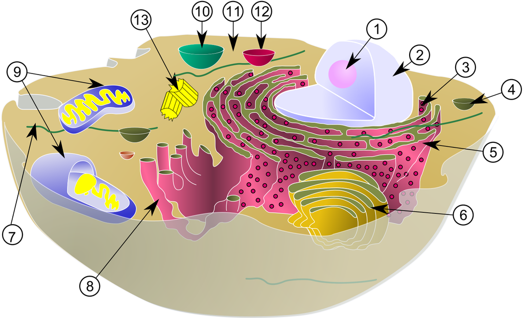

Diagrama d’una cèl·lula animal típica

Font de la imatge: [Diagrama d’una cèl·lula animal típica](https://ca.wikipedia.org/wiki/Fitxer:Biological_cell.svg)

## Secció 3: Estadística descriptiva i contrastos

### Apartat 3.1

Calcula la mitjana, la mediana i la desviació típica de la variable size_uni. Desa els resultats en un vector. Indica breument si els valors obtinguts suggereixen una distribució aproximadament simètrica o no.

**Resposta:**

```r
# calcula la mitjana, la mediana i la desviació típica de size_uni
resum_size_uni <- c(
    mitjana = mean(biopsy_clean$size_uni),
    mediana = median(biopsy_clean$size_uni),
    desviacio_tipica = sd(biopsy_clean$size_uni)
)
# mostra els resultats
resum_size_uni
```

```
##          mitjana          mediana desviacio_tipica
##         3.150805         1.000000         3.065145
```

Els valors obtinguts en les mesures descriptives suggereixen que la distribució de la variable `size_uni` no és aproximadament simètrica. La mitjana (3.1508053) > mediana (1), la distribució està desplaçada cap a la dreta. A més, la desviació típica és relativament alta (3.0651449), el que indica una gran dispersió dels valors al voltant del centre.

### Apartat 3.2

Crea una nova variable anomenada high_mitosis, que prengui el valor “yes” si el valor de mitosis és superior a 5 i “no” en cas contrari. Explica quin tipus de variable és high_mitosis i per què pot resultar útil transformar una variable numèrica en categòrica en aquest context.

**Resposta:**

```r
# creem la variable high_mitosis
biopsy_clean <- biopsy_clean |>
    mutate(high_mitosis = ifelse(mitosis > 5, "yes", "no"))
# mostrem el tipus de variable de high_mitosis
class(biopsy_clean$high_mitosis)
```

```
## [1] "character"
```

```r
# mostrem els nivells de la variable high_mitosis
levels(factor(biopsy_clean$high_mitosis))
```

```
## [1] "no"  "yes"
```

```r
# mostrem el resum estadístic de la variable high_mitosis
summary(factor(biopsy_clean$high_mitosis))
```

```
##  no yes
## 649  34
```

La variable `high_mitosis` és una variable categòrica binària, ja que només pot prendre dos valors: “yes” o “no”. Transformar una variable numèrica en categòrica pot ser útil en aquest context perquè permet classificar les observacions en grups basats en un criteri específic (en aquest cas, el nombre de mitosis). Això pot facilitar l’anàlisi de la relació entre la mitosi i la malignitat, ja que es poden comparar les proporcions de casos amb alta mitosi entre les classes benignes i malignes. A més, les variables categòriques són més fàcils d’interpretar en alguns contextos clínics, on es prefereix parlar de “alta mitosi” en lloc de valors numèrics específics.

### Apartat 3.3

Genera una taula de contingència entre la variable class i la nova variable high_mitosis. Comenta breument quin patró s’observa a la taula.

**Resposta:**

```r
# creem la taula de freqüències absolutes entre class i high_mitosis
taula_freq_absolutes <- table(biopsy_clean$class, biopsy_clean$high_mitosis)
# mostrem la taula de freqüències absolutes
taula_freq_absolutes
```

```
##
##                   no yes
##   benign_case    442   2
##   malignant_case 207  32
```

```r
# creen la taula de contingència a partir de les freqüències absolutes
taula_contingencia <- prop.table(taula_freq_absolutes)
# mostrem la taula de contingència
taula_contingencia
```

```
##
##                           no         yes
##   benign_case    0.647144949 0.002928258
##   malignant_case 0.303074671 0.046852123
```

En la taula de contingència, es pot observar que en la majoria de casos no tenen alta mitosi (“no”), però la proporció de casos amb alta mitosi és significativament més gran en els casos malignes que en els benignes.

### Apartat 3.4

Aplica el test més adequat per analitzar la relació entre la mitosi i la malignitat. Interpreta el valor p.

**Resposta:**

En el cas de tenir taules de contingència amb variables categòriques, podem usar la prova de khi quadrat.

```r
# apliquem la prova de khi quadrat
test_khi <- chisq.test(taula_freq_absolutes)
# mostrem el resultat del test
test_khi
```

```
##
##  Pearson's Chi-squared test with Yates' continuity correction
##
## data:  taula_freq_absolutes
## X-squared = 52.285, df = 1, p-value = 4.799e-13
```

Si mirem el p valor (p-value) en el resultat de la prova podrem determinar si les variables `class` i `high_mitosis` estan relacionades o no. En aquest cas, el p-valor és més petit que 0.05 (p = 0.0000000000004799), la prova és significativa i, per tant, les variables `class` i `high_mitosis` estan relacionades.

## Secció 4: Visualització avançada i modelització lineal

### Apartat 4.1

Amb el paquet ggplot2, crea un gràfic de dispersió que relacioni `size_uni` (eix x) amb `shape_uni` (eix y). Els punts han de tenir colors diferents segons la variable `class`. Comenta breument què suggereix el gràfic sobre la separació entre classes i si sembla que hi ha relació entre `size_uni` i `shape_uni`.

**Resposta:**

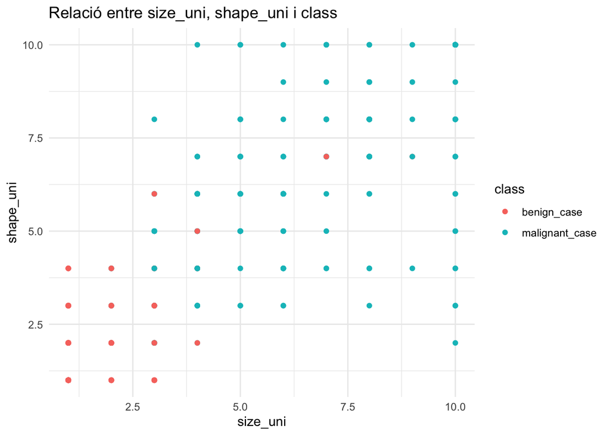

```r
# creem el gràfic de dispersió
ggplot(biopsy_clean, aes(x = size_uni, y = shape_uni, color = class)) +
    geom_point() +
    labs(
        title = "Relació entre size_uni, shape_uni i class",
        x = "size_uni",
        y = "shape_uni",
        color = "class"
    ) +
    theme_minimal()
```

El gràfic mostra una certa separació entre les dues classes: els casos benignes semblen tenir valors més baixos de `size_uni` i `shape_uni`, mentre que els casos malignes tenen valors més alts. Això suggereix que hi ha una relació entre aquestes variables i la classe del tumor.

### Apartat 4.2

Calcula el model de regressió lineal per predir `size_uni` en funció de `thickness`. Mostra el resum del model i comenta el coeficient de determinació. Representa el núvol de punts amb la recta de regressió superposada i comenta si l’ajust sembla raonable.

**Resposta:**

```r
# creem el model de regressió lineal
model <- lm(size_uni ~ thickness, data = biopsy_clean)
# mostrem el resum del model
summary(model)
```

```
##
## Call:
## lm(formula = size_uni ~ thickness, data = biopsy_clean)
##
## Residuals:
##     Min      1Q  Median      3Q     Max
## -6.0310 -1.8421 -0.4458  0.8088  7.8560
##
## Coefficients:
##             Estimate Std. Error t value Pr(>|t|)
## (Intercept)  0.04953    0.16787   0.295    0.768
## thickness    0.69814    0.03191  21.879   <2e-16 ***
## ---
## Signif. codes:  0 '***' 0.001 '**' 0.01 '*' 0.05 '.' 0.1 ' ' 1
##
## Residual standard error: 2.351 on 681 degrees of freedom
## Multiple R-squared:  0.4128, Adjusted R-squared:  0.4119
## F-statistic: 478.7 on 1 and 681 DF,  p-value: < 2.2e-16
```

El coeficient de determinació (R-squared) és 0.4128, el que indica que aproximadament el 41.28% de la variabilitat en la variable `size_uni` es pot explicar només amb la variable `thickness`.

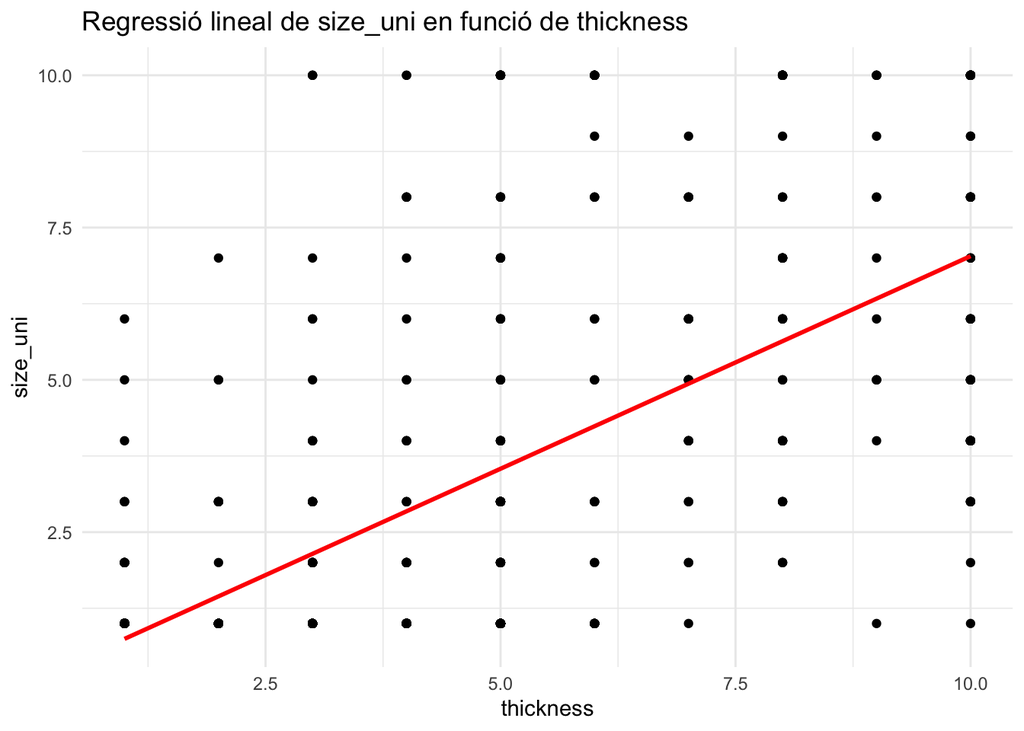

```r
# gràfic de dispersió amb la recta de regressió superposada
# plot(
#     biopsy_clean$thickness, biopsy_clean$size_uni,
#     xlab = "Thickness", ylab = "Size_uni",
#     main = "Regressió lineal de size_uni en funció de thickness"
# )
# abline(model, col = "red")
ggplot(biopsy_clean, aes(x = thickness, y = size_uni)) +
    geom_point() +
    geom_smooth(method = "lm", se = FALSE, color = "red") +
    labs(
        title = "Regressió lineal de size_uni en funció de thickness",
        x = "thickness",
        y = "size_uni"
    ) +
    theme_minimal()
```

El gràfic mostra una tendència positiva entre `thickness` i `size_uni`, però hi ha una gran dispersió dels punts al voltant de la recta de regressió. Això és coherent amb el valor relativament baix del R-squared, indicant que hi ha altres factors que també influeixen en `size_uni`.

### Apartat 4.3

Genera un gràfic per avaluar la normalitat dels residus. Contrasta l’assumpció de normalitat. Interpreta conjuntament el resultat del test i del gràfic.

**Resposta:**

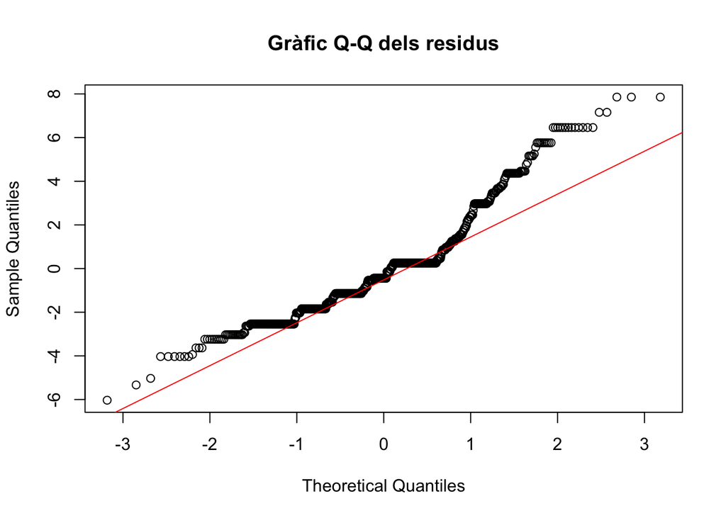

```r
# obtenim els residus del model
residus <- resid(model)
# gràfic Q-Q per avaluar la normalitat dels residus
qqnorm(residus, main = "Gràfic Q-Q dels residus")
qqline(residus, col = "red")
```

```r
# test de Shapiro-Wilk per avaluar la normalitat dels residus
shapiro_test <- shapiro.test(residus)
shapiro_test
```

```
##
##  Shapiro-Wilk normality test
##
## data:  residus
## W = 0.92602, p-value < 2.2e-16
```

### Apartat 4.4

Presenta en una sola finestra un histograma de la variable mitosis i un boxplot de thickness segons la class, personalitzant els colors. Comenta breument les principals característiques d’ambdós gràfics.

**Resposta:**

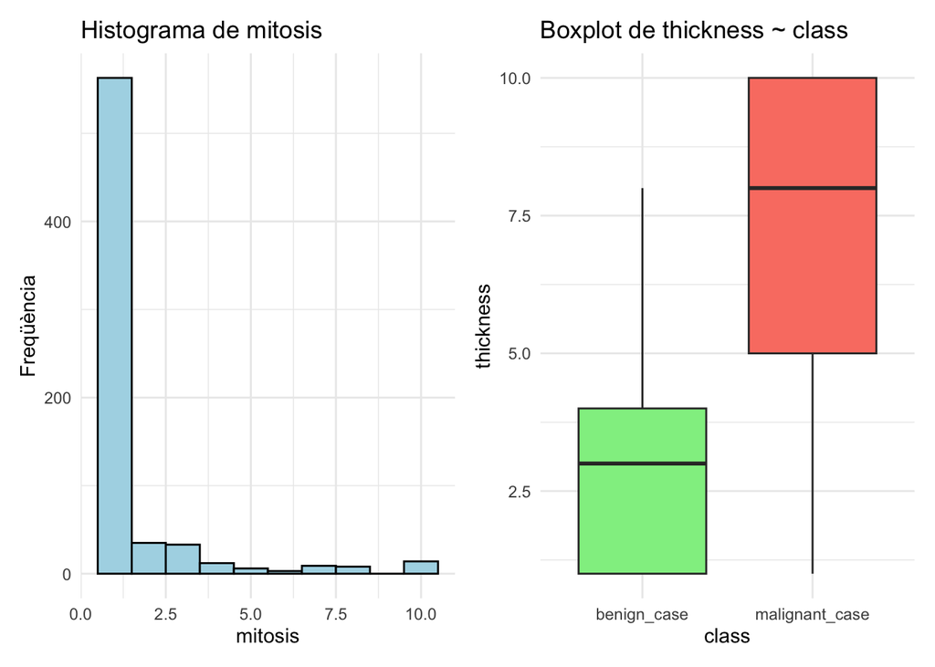

```r
# instal·lar si cal:
# install.packages("patchwork")

library(patchwork)

# histograma de mitosis
histograma_mitosis <- ggplot(biopsy_clean, aes(x = mitosis)) +
    geom_histogram(binwidth = 1, fill = "lightblue", color = "black") +
    labs(title = "Histograma de mitosis", x = "mitosis", y = "Freqüència") +
    theme_minimal()

# boxplot de thickness segons class
boxplot_thickness <- ggplot(
    biopsy_clean,
    aes(x = class, y = thickness, fill = class)
) +
    geom_boxplot() +
    labs(
        title = "Boxplot de thickness ~ class",
        x = "class",
        y = "thickness"
    ) +
    scale_fill_manual(
        values = c(
            "benign_case" = "lightgreen",
            "malignant_case" = "salmon"
        )
    ) +
    theme_minimal() +
    theme(legend.position = "none")

# combinació amb patchwork
histograma_mitosis + boxplot_thickness
```

L’histograma de la variable `mitosis` mostra que la majoria de les observacions tenen un valor de mitosis baix, amb una distribució asimètrica cap a la dreta.

El diagrama de caixa de `thickness` segons `class` mostra que els casos malignes tenen una mediana i una amplitud interquartílica més altes que els casos benignes, indicant que els malignes tendeixen a ser més gruixuts que els benignes.